# MOVES

Joseph Jakuta

5/21/2020

## Overview

The District is undertaking a MOVES excercise as part of planning work. It will require multiple MOVES scenarios to be run. To ease the proess and the replicability (and to improve my R skills) I wrote a MOVES package for R.

Is this perfect. No. Right now I would desribe it as dev. But I have already put it to use and think having a few MOVES experts working on it together could get it to be something to contribute to the larger commmunity.

What it does (so far):

1. Reads in county data manager tables and joins them with applicable descriptive tables
2. Reads in output tables and joins them with applicable descriptive tables
3. Create a county data manager table
4. Replace a county data manager table
5. Run MOVES inline after creation of RunSpec

What it could do:

1. Read in project level tables and join them with applicable descriptive tables
2. Have standard QA plots
3. Expand to be compatible with older versions of MOVES
4. ?What else

Now let’s walk through a script.

## Loading Libraries

Note that this is set up so that the moves library itself calls the database library. Theoretically MarieDB shoudl be easily swapped in to that library.

```r
library(r4moves)
library(dplyr)
library(ggplot2)
```

## Set Up DB Connections

Here we are going to set all of the variables we are going to need and make a connection to the MOVES database:

```r
password <- 'K7j0Ret79TwUIjxZExbZ'
movesdb_name <- 'movesdb20180517'
countydb_name <- 'ozn_dc_2017_naaq_in'
outputdb_name <- 'ozn_dc_2017_naaq_out'

dbconn <- makeDBConnection(user = 'root', password=password)
```

## Get a Table

Here is an example fecth of an input table:

```r
data <- getAverageSpeedBin(dbconn, movesdb_name, countydb_name)
print(head(data,5))
```

```
##   avgSpeedFraction hourDayID dayID hourID avgSpeedBinID avgBinSpeed
## 1                0        15     5      1             1         2.5
## 2                0        15     5      1             2         5.0
## 3                0        15     5      1             3        10.0
## 4                0        15     5      1             4        15.0
## 5                0        15     5      1             5        20.0
##              avgSpeedBinDesc opModeIDTirewear opModeIDRunning roadTypeID
## 1             speed < 2.5mph              401              NA          2
## 2   2.5mph <= speed < 7.5mph              402              NA          2
## 3  7.5mph <= speed < 12.5mph              403              NA          2
## 4 12.5mph <= speed < 17.5mph              404              NA          2
## 5  17.5mph <= speed <22.5mph              405              NA          2
##                  roadDesc rampFraction isAffectedByOnroad isAffectedByNonroad
## 1 Rural Restricted Access         0.08                  1                   0
## 2 Rural Restricted Access         0.08                  1                   0
## 3 Rural Restricted Access         0.08                  1                   0
## 4 Rural Restricted Access         0.08                  1                   0
## 5 Rural Restricted Access         0.08                  1                   0
##   shouldDisplay sourceTypeID HPMSVtypeID sourceTypeName  dayName noOfRealDays
## 1             1           11          10     Motorcycle Weekdays            5
## 2             1           11          10     Motorcycle Weekdays            5
## 3             1           11          10     Motorcycle Weekdays            5
## 4             1           11          10     Motorcycle Weekdays            5
## 5             1           11          10     Motorcycle Weekdays            5
##   HPMSVtypeName
## 1   Motorcycles
## 2   Motorcycles
## 3   Motorcycles
## 4   Motorcycles
## 5   Motorcycles
```

## DPLYR

Then you can use DPLYR to make nice summaries:

```r
data_sub <- data %>%
  filter(dayName == "Weekdays" & roadDesc == "Urban Restricted Access") %>%
  select(avgSpeedFraction, avgSpeedBinID, avgBinSpeed,sourceTypeID, sourceTypeName, hourID)


data_sub <- data_sub %>%
  group_by(avgSpeedBinID, avgBinSpeed, sourceTypeID, sourceTypeName) %>%
  summarize(avgSpeedFraction = mean(avgSpeedFraction))

print(head(data_sub,5))
```

```
## # A tibble: 5 x 5
## # Groups:   avgSpeedBinID, avgBinSpeed, sourceTypeID [5]
##   avgSpeedBinID avgBinSpeed sourceTypeID sourceTypeName         avgSpeedFraction
##           <int>       <dbl>        <int> <chr>                             <dbl>
## 1             1         2.5           11 Motorcycle                            0
## 2             1         2.5           21 Passenger Car                         0
## 3             1         2.5           31 Passenger Truck                       0
## 4             1         2.5           32 Light Commercial Truck                0
## 5             1         2.5           41 Intercity Bus                         0
```

## GGPLOT

Then you can use GGPLOT to make nice QA graphs (though this is not that):

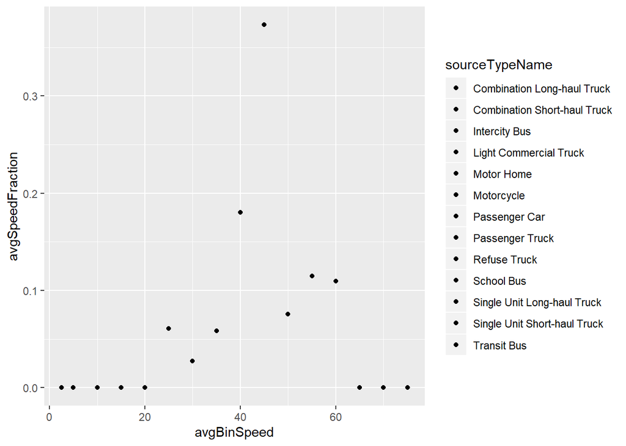

```r
plot <-  ggplot(data_sub, aes(avgBinSpeed, avgSpeedFraction, fill=sourceTypeName)) +
  geom_point()
plot
```

## Create New Test Database

You can then manipulate data to run scenarios:

```r
data <- getIMCoverage(dbconn, movesdb_name, countydb_name)
print(head(data,2))
```

```
##   yearID inspectFreq IMProgramID begModelYearID endModelYearID useIMyn
## 1   2017           2         111           1968           1983       Y
## 2   2017           2         111           1968           1983       Y
##   complianceFactor polProcessID processID pollutantID isAffectedByExhaustIM
## 1            93.12          101         1           1                     Y
## 2            93.12          102         2           1                     Y
##   isAffectedByEvapIM chainedto1 chainedto2 isAffectedByOnroad
## 1                  N         NA         NA                  1
## 2                  N         NA         NA                  1
##   isAffectedByNonroad nrChainedTo1 nrChainedTo2 stateID            stateName
## 1                   1           NA           NA      11 DISTRICT OF COLUMBIA
## 2                   0           NA           NA      11 DISTRICT OF COLUMBIA
##   stateAbbr countyID           countyName altitude GPAFract barometricPressure
## 1        DC    11001 District of Columbia        L        0             29.739
## 2        DC    11001 District of Columbia        L        0             29.739
##   barometricPressureCV sourceTypeID HPMSVtypeID sourceTypeName fuelTypeID
## 1                   NA           21          25  Passenger Car          1
## 2                   NA           21          25  Passenger Car          1
##   defaultFormulationID fuelTypeDesc humidityCorrectionCoeff
## 1                   10     Gasoline                  0.0038
## 2                   10     Gasoline                  0.0038
##   humidityCorrectionCoeffCV fuelDensity subjectToEvapCalculations
## 1                        NA        2839                         Y
## 2                        NA        2839                         Y
##   testStandardsID  testStandardsDesc     shortName              pollutantName
## 1              11 Unloaded Idle Test Unloaded Idle Total Gaseous Hydrocarbons
## 2              11 Unloaded Idle Test Unloaded Idle Total Gaseous Hydrocarbons
##   energyOrMass globalWarmingPotential NEIPollutantCode pollutantDisplayGroupID
## 1         mass                     NA               HC                      30
## 2         mass                     NA               HC                      30
##       processName SCCProcID occursOnRealRoads processDisplayGroupID
## 1 Running Exhaust         X                 Y                    NA
## 2   Start Exhaust         X                 N                    NA
```

```r
newdata <- data[]
newdata$inspectFreq <- 1
print(head(newdata,2))
```

```
##   yearID inspectFreq IMProgramID begModelYearID endModelYearID useIMyn
## 1   2017           1         111           1968           1983       Y
## 2   2017           1         111           1968           1983       Y
##   complianceFactor polProcessID processID pollutantID isAffectedByExhaustIM
## 1            93.12          101         1           1                     Y
## 2            93.12          102         2           1                     Y
##   isAffectedByEvapIM chainedto1 chainedto2 isAffectedByOnroad
## 1                  N         NA         NA                  1
## 2                  N         NA         NA                  1
##   isAffectedByNonroad nrChainedTo1 nrChainedTo2 stateID            stateName
## 1                   1           NA           NA      11 DISTRICT OF COLUMBIA
## 2                   0           NA           NA      11 DISTRICT OF COLUMBIA
##   stateAbbr countyID           countyName altitude GPAFract barometricPressure
## 1        DC    11001 District of Columbia        L        0             29.739
## 2        DC    11001 District of Columbia        L        0             29.739
##   barometricPressureCV sourceTypeID HPMSVtypeID sourceTypeName fuelTypeID
## 1                   NA           21          25  Passenger Car          1
## 2                   NA           21          25  Passenger Car          1
##   defaultFormulationID fuelTypeDesc humidityCorrectionCoeff
## 1                   10     Gasoline                  0.0038
## 2                   10     Gasoline                  0.0038
##   humidityCorrectionCoeffCV fuelDensity subjectToEvapCalculations
## 1                        NA        2839                         Y
## 2                        NA        2839                         Y
##   testStandardsID  testStandardsDesc     shortName              pollutantName
## 1              11 Unloaded Idle Test Unloaded Idle Total Gaseous Hydrocarbons
## 2              11 Unloaded Idle Test Unloaded Idle Total Gaseous Hydrocarbons
##   energyOrMass globalWarmingPotential NEIPollutantCode pollutantDisplayGroupID
## 1         mass                     NA               HC                      30
## 2         mass                     NA               HC                      30
##       processName SCCProcID occursOnRealRoads processDisplayGroupID
## 1 Running Exhaust         X                 Y                    NA
## 2   Start Exhaust         X                 N                    NA
```

```r
suffix <- "_scenario1"
new_countydb_name <- paste(countydb_name, suffix, sep="")
#copyMOVESDatabase(dbconn, countydb_name, new_countydb_name)
replaceMOVESTable(dbconn,new_countydb_name, "imcoverage", newdata)
```

## Running MOVES - Set Some Variables

Now we are going to run MOVES. You can start by setting some variables. All are needed for option 1 for running MOVES, only the first two are needed for option 2.

```r
moves_location <- "C:\\Users\\Public\\EPA\\MOVES\\MOVES2014b"
folder <- input_runspec <- "C:\\Users\\joseph.jakuta\\Desktop\\"
input_runspec <- paste(folder, "test_runspec.xml", sep='')
output_runspec <- paste(folder, "test_runspec_new.mrs", sep='')
batchfile <- paste(folder, "test_batch.bat", sep='')
```

## Running MOVES - Maninpulate the RUNSPEC

These functions can get variables (except the description) and set variables (except the description) in the Runspec. These are

```r
rs <- readRunspec(input_runspec)
getRunspecAttr(rs, "//scaleinputdatabase", "databasename")
```

```
## [1] "ozn_dc_2017_naaq_in"
```

```r
print(rs)
```

```
## <?xml version="1.0"?>
## <runspec version="MOVES2014b-20180726">
##   <description><![CDATA[]]></description>
##   <models>
##     <model value="ONROAD"/>
##   </models>
##   <modelscale value="Inv"/>
##   <modeldomain value="SINGLE"/>
##   <geographicselections>
##     <geographicselection type="COUNTY" key="11001" description="DISTRICT OF COLUMBIA - District of Columbia"/>
##   </geographicselections>
##   <timespan>
##     <year key="2017"/>
##     <month id="1"/>
##     <month id="2"/>
##     <month id="3"/>
##     <month id="4"/>
##     <month id="5"/>
##     <month id="6"/>
##     <month id="7"/>
##     <month id="8"/>
##     <month id="9"/>
##     <month id="10"/>
##     <month id="11"/>
##     <month id="12"/>
##     <day id="2"/>
##     <day id="5"/>
##     <beginhour id="1"/>
##     <endhour id="24"/>
##     <aggregateBy key="Hour"/>
##   </timespan>
##   <onroadvehicleselections>
##     <onroadvehicleselection fueltypeid="3" fueltypedesc="Compressed Natural Gas (CNG)" sourcetypeid="42" sourcetypename="Transit Bus"/>
##     <onroadvehicleselection fueltypeid="2" fueltypedesc="Diesel Fuel" sourcetypeid="62" sourcetypename="Combination Long-haul Truck"/>
##     <onroadvehicleselection fueltypeid="2" fueltypedesc="Diesel Fuel" sourcetypeid="61" sourcetypename="Combination Short-haul Truck"/>
##     <onroadvehicleselection fueltypeid="2" fueltypedesc="Diesel Fuel" sourcetypeid="41" sourcetypename="Intercity Bus"/>
##     <onroadvehicleselection fueltypeid="2" fueltypedesc="Diesel Fuel" sourcetypeid="32" sourcetypename="Light Commercial Truck"/>
##     <onroadvehicleselection fueltypeid="2" fueltypedesc="Diesel Fuel" sourcetypeid="54" sourcetypename="Motor Home"/>
##     <onroadvehicleselection fueltypeid="2" fueltypedesc="Diesel Fuel" sourcetypeid="21" sourcetypename="Passenger Car"/>
##     <onroadvehicleselection fueltypeid="2" fueltypedesc="Diesel Fuel" sourcetypeid="31" sourcetypename="Passenger Truck"/>
```

[output cut: 81 more lines]

```
##   <pmsize value="0"/>
##   <outputfactors>
##     <timefactors selected="true" units="Hours"/>
##     <distancefactors selected="true" units="Miles"/>
##     <massfactors selected="true" units="Pounds" energyunits="Million BTU"/>
##   </outputfactors>
##   <savedata>
##  </savedata>
##   <donotexecute>
##  </donotexecute>
##   <generatordatabase shouldsave="false" servername="" databasename="" description=""/>
##   <donotperformfinalaggregation selected="false"/>
##   <lookuptableflags scenarioid="" truncateoutput="true" truncateactivity="true" truncatebaserates="true"/>
## </runspec>
##
```

```r
setRunspecAttr(rs, "//outputdatabase", c(databasename =  new_countydb_name))
```

```
## [[1]]
##                    databasename
## "ozn_dc_2017_naaq_in_scenario1"
```

```r
print(rs)
```

```
## <?xml version="1.0"?>
## <runspec version="MOVES2014b-20180726">
##   <description><![CDATA[]]></description>
##   <models>
##     <model value="ONROAD"/>
##   </models>
##   <modelscale value="Inv"/>
##   <modeldomain value="SINGLE"/>
##   <geographicselections>
##     <geographicselection type="COUNTY" key="11001" description="DISTRICT OF COLUMBIA - District of Columbia"/>
##   </geographicselections>
##   <timespan>
##     <year key="2017"/>
##     <month id="1"/>
##     <month id="2"/>
##     <month id="3"/>
##     <month id="4"/>
##     <month id="5"/>
##     <month id="6"/>
##     <month id="7"/>
##     <month id="8"/>
##     <month id="9"/>
##     <month id="10"/>
##     <month id="11"/>
##     <month id="12"/>
##     <day id="2"/>
##     <day id="5"/>
##     <beginhour id="1"/>
##     <endhour id="24"/>
##     <aggregateBy key="Hour"/>
##   </timespan>
##   <onroadvehicleselections>
##     <onroadvehicleselection fueltypeid="3" fueltypedesc="Compressed Natural Gas (CNG)" sourcetypeid="42" sourcetypename="Transit Bus"/>
##     <onroadvehicleselection fueltypeid="2" fueltypedesc="Diesel Fuel" sourcetypeid="62" sourcetypename="Combination Long-haul Truck"/>
##     <onroadvehicleselection fueltypeid="2" fueltypedesc="Diesel Fuel" sourcetypeid="61" sourcetypename="Combination Short-haul Truck"/>
##     <onroadvehicleselection fueltypeid="2" fueltypedesc="Diesel Fuel" sourcetypeid="41" sourcetypename="Intercity Bus"/>
##     <onroadvehicleselection fueltypeid="2" fueltypedesc="Diesel Fuel" sourcetypeid="32" sourcetypename="Light Commercial Truck"/>
##     <onroadvehicleselection fueltypeid="2" fueltypedesc="Diesel Fuel" sourcetypeid="54" sourcetypename="Motor Home"/>
##     <onroadvehicleselection fueltypeid="2" fueltypedesc="Diesel Fuel" sourcetypeid="21" sourcetypename="Passenger Car"/>
##     <onroadvehicleselection fueltypeid="2" fueltypedesc="Diesel Fuel" sourcetypeid="31" sourcetypename="Passenger Truck"/>
```

[output cut: 81 more lines]

```
##   <pmsize value="0"/>
##   <outputfactors>
##     <timefactors selected="true" units="Hours"/>
##     <distancefactors selected="true" units="Miles"/>
##     <massfactors selected="true" units="Pounds" energyunits="Million BTU"/>
##   </outputfactors>
##   <savedata>
##  </savedata>
##   <donotexecute>
##  </donotexecute>
##   <generatordatabase shouldsave="false" servername="" databasename="" description=""/>
##   <donotperformfinalaggregation selected="false"/>
##   <lookuptableflags scenarioid="" truncateoutput="true" truncateactivity="true" truncatebaserates="true"/>
## </runspec>
##
```

## Running MOVES - Option 1

Three funcitons are needed to run MOVES in the first fashion. This is being discussed mostly to show its available. I suggest using method 2.

```r
createTempRunspec(rs, output_runspec)
```

```
## [1] "C:\\Users\\joseph.jakuta\\Desktop\\test_runspec_new.mrs"
```

```r
createTempBatchFile(batchfile, c(output_runspec), moves_location)
runMOVES(batchfile)
```

```
##  [1] "Changing to the MOVES folder and compiling code..."
##  [2] "Unable to locate tools.jar. Expected to find it in C:\\Program Files\\Java\\jre1.8.0_201\\lib\\tools.jar"
##  [3] "Buildfile: build.xml"
##  [4] ""
##  [5] "init:"
##  [6] ""
##  [7] "compile:"
##  [8] ""
##  [9] "BUILD SUCCESSFUL"
## [10] "Total time: 0 seconds"
## [11] "Running test_11001_2017_test.mrs"
## [12] "5/21/20 3:13 PM INFO: Loading system configuration..."
## [13] "5/21/20 3:13 PM INFO: System configuration setting up the instance counter..."
## [14] "5/21/20 3:13 PM INFO: System configuration clearing prior IDs..."
## [15] "5/21/20 3:13 PM INFO: System configuration reading computer ID..."
```

[output cut: 17 more lines]

## Running MOVES - Option 2

```r
createTempFilesAndRunMOVES(c(rs), folder, moves_location)
```

```
## [1] "C:\\Users\\joseph.jakuta\\Desktop\\r4moves.bat"
```

```
##  [1] "Changing to the MOVES folder and compiling code..."
##  [2] "Unable to locate tools.jar. Expected to find it in C:\\Program Files\\Java\\jre1.8.0_201\\lib\\tools.jar"
##  [3] "Buildfile: build.xml"
##  [4] ""
##  [5] "init:"
##  [6] ""
##  [7] "compile:"
##  [8] ""
##  [9] "BUILD SUCCESSFUL"
## [10] "Total time: 0 seconds"
## [11] "Running test_11001_2017_test.mrs"
## [12] "5/21/20 3:13 PM INFO: Loading system configuration..."
## [13] "5/21/20 3:13 PM INFO: System configuration setting up the instance counter..."
## [14] "5/21/20 3:13 PM INFO: System configuration clearing prior IDs..."
## [15] "5/21/20 3:13 PM INFO: System configuration reading computer ID..."
```

[output cut: 17 more lines]

## Get Output

Get the run data and display.

```r
by_or_moves_data_run <- getMOVESRun(dbconn, movesdb_name, outputdb_name)
print(by_or_moves_data_run)
```

```
##   MOVESRunID outputTimePeriod timeUnits distanceUnits massUnits energyUnits
## 1          1              Day       day            mi       ton           J
##                                                                                                 runSpecFileName
## 1 C:\\MOVES\\MOVES2014b\\Application\\2015_OZONE_SIP\\EMP1_0_0\\INPUT\\Runspec\\2017_NAAQ\\OZN_DC_2017_NAAQ.MRS
##   runSpecDescription runSpecFileDateTime         runDateTime scale
## 1           OZONE DC 2019-08-22 15:58:03 2019-08-22 16:09:07   Inv
##   minutesDuration defaultDatabaseUsed       masterVersion masterComputerID
## 1         33.7629     movesdb20181022 MOVES2014b-20181203         DTP277B1
##        masterIDNumber domain domainCountyID     domainCountyName
## 1 6027708299530886042 SINGLE          11001 District of Columbia
##   domainDatabaseServer  domainDatabaseName expectedDONEFiles retrievedDONEFiles
## 1            localhost OZN_DC_2017_NAAQ_IN                61                 61
##   models
## 1 onroad
```

Get the output data and summarize (July only run). Note that even though it isnt’t in the the DB the weekdays and weekends of the month are added to the dataframe.

```r
by_or_moves_data <- getMOVESOutput(dbconn, movesdb_name, outputdb_name)
summary <-by_or_moves_data %>%
  filter(pollutantName %in% c("Carbon Monoxide (CO)","Oxides of Nitrogen (NOx)","Non-Methane Hydrocarbons")) %>%
  group_by(monthName, pollutantName) %>%
  summarise(TotalEmissions = sum(emissionQuant*ifelse(dayID == 2, weekendsInMonth, weekdaysInMonth)))

print(summary)
```

```
## # A tibble: 3 x 3
## # Groups:   monthName [1]
##   monthName pollutantName            TotalEmissions
##   <chr>     <chr>                             <dbl>
## 1 July      Carbon Monoxide (CO)             1154.
## 2 July      Non-Methane Hydrocarbons           76.6
## 3 July      Oxides of Nitrogen (NOx)          118.
```

## Close DB Connection

```r
endDBConnection(dbconn)
```

```
## [1] TRUE
```